# Diagnostics

Dr. Lucy D’Agostino McGowan

## We Assume

- Linearity
- Constant variance
- Normality of errors
- Independence
- Randomness
- Errors have mean 0

## We Assume

- **Linearity**
- **Constant variance**
- **Normality of errors**
- Independence
- Randomness
- Errors have mean 0

## Residuals vs. Errors

Errors $\varepsilon_i$ are not observable

We can instead examine residuals $\hat{\varepsilon}_i$
$$\hat{\varepsilon}_i = y_i - \hat{y}_i$$

# Checking Constant Variance

## The Assumption

**Homoscedasticity:** $\text{Var}(\varepsilon_i) = \sigma^2$ for all $i$

**What we want:** Constant spread in residuals across all fitted values

## Residuals vs. Fitted Plot

**The diagnostic:**  
Plot $\hat{\varepsilon}_i$ vs. $\hat{y}_i$

**What to look for:**  
- Random scatter around zero  
- Constant spread (no funnel shape)  
- No patterns or trends

## Example: Good vs. Bad

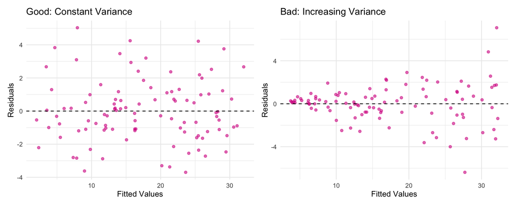

## Creating the Plot in R

```r
# Fit model
model <- lm(y ~ x1 + x2)

library(ggplot2)
ggplot(data.frame(fitted = fitted(model),
                  resid = residuals(model)),
       aes(x = fitted, y = resid)) +
  geom_point() +
  geom_hline(yintercept = 0, linetype = "dashed") +
  labs(x = "Fitted Values", y = "Residuals") +
  theme_minimal()
```

# Checking Normality

## The Assumption

**Normality:** $\varepsilon_i \sim N(0, \sigma^2)$

**Tool:** Q-Q Plot (Quantile-Quantile Plot)

**Good news:** CLT helps a lot!  
- Coverage probabilities are robust to non-normality  
- With moderate sample sizes, normality violations are often okay  
- We can generally ignore minor deviations

## Q-Q Plot

**How it works:**  
- Plot sample quantiles vs. theoretical normal quantiles  
- If residuals are normal, points fall on a straight line

## Example Q-Q Plots

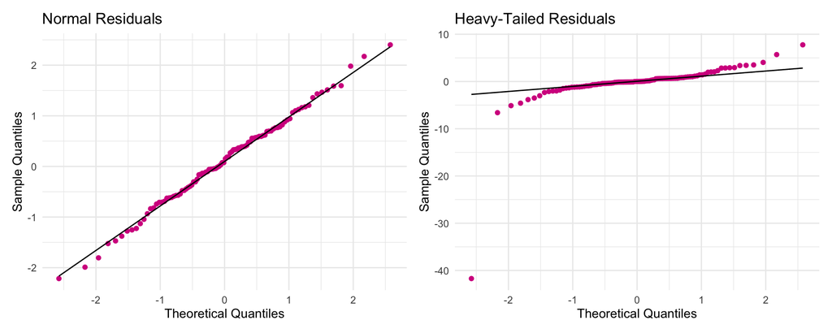

## Q-Q Plot in R

```r
ggplot(data.frame(resid = residuals(model)),
       aes(sample = resid)) +
  stat_qq() +
  stat_qq_line() +
  labs(x = "Theoretical Quantiles", y = "Sample Quantiles") +
  theme_minimal()
```

## When Errors Are Not Normal

**The reality:** Coverage is usually fine!

**Why?** Central Limit Theorem kicks in pretty well

# Outliers and Influential Points

## Three Types of Problematic Points

**1. Outliers:** Points that don’t fit the model well  
- Large residuals  
- May or may not affect model fit

**2. High Leverage Points:** Extreme in predictor space  
- Far from center of $X$ values  
- Have potential to influence fit

**3. Influential Points:** Actually change the model fit  
- Combine large residual with high leverage  
- Removing them substantially changes $\hat{\boldsymbol{\beta}}$

## Leverage

**Definition:** Diagonal elements of the hat matrix
$$h_i = H_{ii} \text{ where } \mathbf{H} = \mathbf{X}(\mathbf{X}^T\mathbf{X})^{-1}\mathbf{X}^T$$

**Properties:**

- $\sum_{i=1}^n h_i = p$ (where $p$ = number of parameters)
- Average leverage: $\bar{h} = p/n$ (Check points with $h_i > 2p/n$)

## Why Leverage Matters

**Variance of residuals:**
$$\text{Var}(\hat{\varepsilon}_i) = \sigma^2(1 - h_i)$$

Large $h_i$ makes residual small!

## Standardized Residuals

**Problem:** Raw residuals have different variances

**Solution:** Standardize by their standard deviation
$$r_i = \frac{\hat{\varepsilon}_i}{\hat{\sigma}\sqrt{1-h_i}}$$

## Standardized Residuals

- Approximately follows standard normal (if assumptions hold)
- Values beyond ±2 or ±3 suggest outliers

## Studentized Residuals

**Even better:** Use leave-one-out estimate of $\sigma$
$$t_i = \frac{\hat{\varepsilon}_i}{\hat{\sigma}_{(i)}\sqrt{1-h_i}}$$
where $\hat{\sigma}_{(i)}$ is computed without observation $i$

**Why?** Doesn’t let outlier affect its own diagnostic

**Distribution:** Follows $t_{n-p-1}$ distribution exactly

## Computing Standardized Residuals in R

```r
set.seed(1)
x <- 1:20
y <- 2 + 3 * x + rnorm(20)
y[20] <- 80
model <- lm(y ~ x)

# Standardized residuals
std_resid <- rstandard(model)

# Studentized residuals
stud_resid <- rstudent(model)

# Compare
tail(data.frame(
  obs = 1:20,
  standardized = round(std_resid, 2),
  studentized = round(stud_resid, 2)
))
```

## Computing Standardized Residuals in R

```
   obs standardized studentized
15  15        -0.31       -0.30
16  16        -0.70       -0.69
17  17        -0.78       -0.77
18  18        -0.60       -0.58
19  19        -0.72       -0.71
20  20         4.12       16.69
```

## The Danger of Automatic Exclusion

**Outliers can be:**

- Errors (typos, measurement problems)
- The most interesting part of your data!
- Evidence that your model is wrong
- A real phenomenon you need to understand

**Never automatically exclude outliers**  
Investigate them carefully first!

# Influential Points: Cook’s Distance

## What is Cook’s Distance?

**Measures:** How much the fitted values change if we remove observation $i$

**Formula:**
$$D_i = \frac{(\hat{y}-\hat{y}_{(i)})^T(\hat{y}-\hat{y}_{(i)})}{p\hat{\sigma}^2}$$
where $\hat{y}_{(i)}$ are the fitted values when observation $i$ is removed

**Alternative form:**
$$D_i = \frac{r_i^2}{p} \cdot \frac{h_i}{1-h_i}$$
Combines residual size and leverage!

## Cook’s Distance in R

```r
# Using previous model with outlier
cooks_d <- cooks.distance(model)

# Plot
ggplot(data.frame(obs = 1:20, cooks = cooks_d),
       aes(x = obs, y = cooks)) +
  geom_segment(aes(xend = obs, yend = 0), color = "#d5008f") +
  geom_point(color = "#d5008f", size = 2) +
  geom_hline(yintercept = 4/20, linetype = "dashed") +
  labs(title = "Cook's Distance", x = "Observation", y = "Cook's Distance") +
  theme_minimal()
```

## Cook’s Distance in R

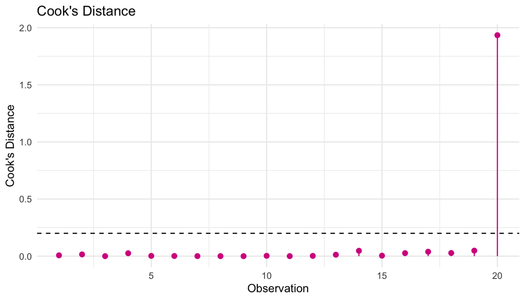

# Checking Linearity

## Partial Regression Plots

**Purpose:** Isolate the effect of $x_j$ on $y$ after accounting for other predictors

**How it works:**  
1. Regress $y$ on all predictors except $x_j$ → get residuals $e_y$  
2. Regress $x_j$ on all other predictors → get residuals $e_x$  
3. Plot $e_y$ vs. $e_x$  
4. Should see linear relationship if model is correct

## Why Partial Regression Plots Help

**Benefits:**

- Shows relationship between $y$ and $x_j$ controlling for other variables
- Helps detect non-linearity for individual predictors
- Can reveal need for transformations
- Shows influence of individual points on that coefficient

The slope of the partial regression plot equals $\hat{\beta}_j$

## Partial Regression Plot Example

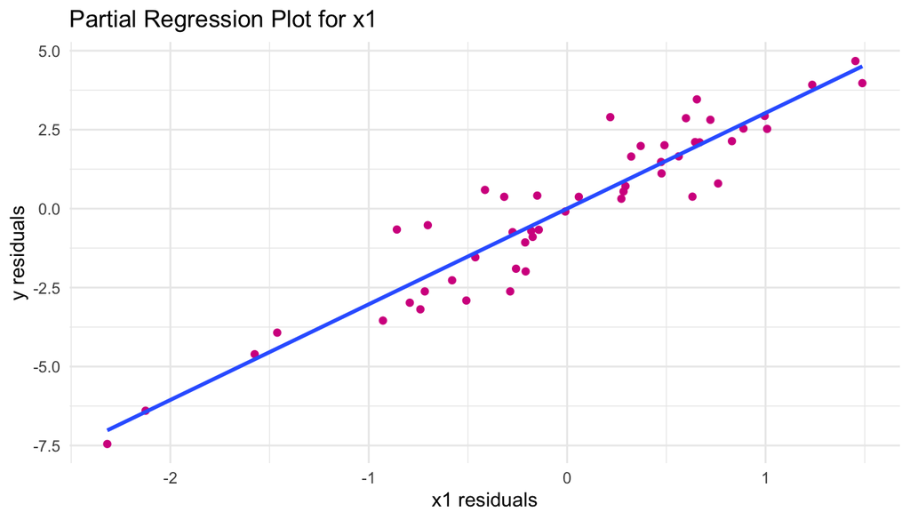

## Partial Regression Plots in R

```r
model_full <- lm(y ~ x1 + x2)
e_y <- residuals(lm(y ~ x2))
e_x1 <- residuals(lm(x1 ~ x2))

ggplot(data.frame(e_x1, e_y), aes(x = e_x1, y = e_y)) +
  geom_point() +
  geom_smooth(method = "lm", se = FALSE, formula = y ~ x) +
  labs(x = "x1 residuals", y = "y residuals") +
  theme_minimal()
```

## Conditions for OLS

| Assumption | What it means | How do you check? | How do you fix? |
| --- | --- | --- | --- |
| Linearity | The relationship between the outcome and explanatory variable or predictor is linear **holding all other variables constant** | Residuals vs. fits plot Partial regression plots | fit a better model (transformations, polynomial terms, more / different variables, etc.) |

## Conditions for OLS

| Assumption | What it means | How do you check? | How do you fix? |
| --- | --- | --- | --- |
| Linearity | The relationship between the outcome and explanatory variable or predictor is linear **holding all other variables constant** | Residuals vs. fits plot Partial regression plots | fit a better model (**transformations**, polynomial terms, more / different variables, etc.) |

## Conditions for OLS

| Assumption | What it means | How do you check? | How do you fix? |
| --- | --- | --- | --- |
| Linearity | The relationship between the outcome and explanatory variable or predictor is linear **holding all other variables constant** | Residuals vs. fits plot **Partial regression plots** | fit a better model (transformations, polynomial terms, more / different variables, etc.) |

## Conditions for OLS

| Assumption | What it means | How do you check? | How do you fix? |
| --- | --- | --- | --- |
| Linearity | The relationship between the outcome and explanatory variable or predictor is linear **holding all other variables constant** | Residuals vs. fits plot Partial regression plots | fit a better model (transformations, polynomial terms, more / different variables, etc.) |
| Zero Mean |  |  |  |

## Conditions for OLS

| Assumption | What it means | How do you check? | How do you fix? |
| --- | --- | --- | --- |
| Linearity | The relationship between the outcome and explanatory variable or predictor is linear **holding all other variables constant** | Residuals vs. fits plot Partial regression plots | fit a better model (transformations, polynomial terms, more / different variables, etc.) |
| Zero Mean | The error distribution is centered at zero | by default | – |
| Constant Variance |  |  |  |

## Conditions for OLS

| Assumption | What it means | How do you check? | How do you fix? |
| --- | --- | --- | --- |
| Linearity | The relationship between the outcome and explanatory variable or predictor is linear **holding all other variables constant** | Residuals vs. fits plot Partial regression plots | fit a better model (transformations, polynomial terms, more / different variables, etc.) |
| Zero Mean | The error distribution is centered at zero | by default | – |
| Constant Variance | The variability in the errors is the same for all values of the predictor variable | Residuals vs.fits plot | fit a better model (try taking the log or square root of the outcome) |
| Independence |  |  |  |

## Conditions for OLS

| Assumption | What it means | How do you check? | How do you fix? |
| --- | --- | --- | --- |
| Linearity | The relationship between the outcome and explanatory variable or predictor is linear **holding all other variables constant** | Residuals vs. fits plot Partial regression plots | fit a better model (transformations, polynomial terms, more / different variables, etc.) |
| Zero Mean | The error distribution is centered at zero | by default | – |
| Constant Variance | The variability in the errors is the same for all values of the predictor variable | Residuals vs.fits plot | fit a better model (try taking the log or square root of the outcome) |
| Independence | The errors are assumed to be independent from one another | 👀 data generation | Find better data or fit a fancier model |
| Random |  |  |  |

## Conditions for OLS

| Assumption | What it means | How do you check? | How do you fix? |
| --- | --- | --- | --- |
| Linearity | The relationship between the outcome and explanatory variable or predictor is linear **holding all other variables constant** | Residuals vs. fits plot Partial regression plots | fit a better model (transformations, polynomial terms, more / different variables, etc.) |
| Zero Mean | The error distribution is centered at zero | by default | – |
| Constant Variance | The variability in the errors is the same for all values of the predictor variable | Residuals vs.fits plot | fit a better model (try taking the log or square root of the outcome) |
| Independence | The errors are assumed to be independent from one another | 👀 data generation | Find better data or fit a fancier model |
| Random | The data are obtained using a random process | 👀 data generation | Find better data |
| Normality |  |  |  |

## Conditions for OLS

| Assumption | What it means | How do you check? | How do you fix? |
| --- | --- | --- | --- |
| Linearity | The relationship between the outcome and explanatory variable or predictor is linear **holding all other variables constant** | Residuals vs. fits plot Partial regression plots | fit a better model (transformations, polynomial terms, more / different variables, etc.) |
| Zero Mean | The error distribution is centered at zero | by default | – |
| Constant Variance | The variability in the errors is the same for all values of the predictor variable | Residuals vs.fits plot | fit a better model (try taking the log or square root of the outcome) |
| Independence | The errors are assumed to be independent from one another | 👀 data generation | Find better data or fit a fancier model |
| Random | The data are obtained using a random process | 👀 data generation | Find better data |
| Normality | The random errors follow a normal distribution | QQ-plot | Get more data |